# Strings and factors

Most of the tools we examined in Data Wrangling I were general purpose things – what tidy data is, using `dplyr` and `tidyr` for manipulation of data tables. Two variable types, strings and factors, present enough challenges to examine in some detail. Now might also be a good time to read up on the [history](https://simplystatistics.org/2015/07/24/stringsasfactors-an-unauthorized-biography/) of strings and factors in R!

This is the second module in the Data Wrangling II topic.

## Overview

### Learning Objectives

Edit/manipulate strings and take control of factors.

### Slide Deck

[interactive chart not shown]

**[Strings and Factors](https://speakerdeck.com/jeffgoldsmith/p8105-strings-and-factors)** from **[Jeff Goldsmith](https://speakerdeck.com/jeffgoldsmith)**.

### Video Lecture

[video not shown]

## Example

I’ll write code for today’s content in a new R Markdown document called `strings_and_factors.Rmd`, and put it in the same directory / GitHub repo as `reading_data.Rmd`. Since we’ll revisit some scraped examples, I’ll load `rvest` now; we’ll also use some datasets in `p8105.datasets` so I’ll load that as well. And finally, we’ll use some of these examples, so I’ll make sure I have them in a `data` subdirectory..

```r
library(rvest)
library(p8105.datasets)
```

### Strings and regex

Lots of the examples below are drawn from materials by [Jeff Leek](https://docs.google.com/presentation/d/1rLNJVyWuIEQqkqTWUlCY4G-l7H610wM1IRz3CL67Gec).

The most frequent operation involving strings is to search for an exact match. You can use `str_detect` to find cases where the match exists (often useful in conjunction with `filter`), and you can use `str_replace` to replace an instance of a match with something else (often useful in conjunction with `mutate`). In the following examples we’ll mostly focus on vectors to avoid the complication of data frames, but we’ll see those shortly.

```r
string_vec = c("my", "name", "is", "jeff")

str_detect(string_vec, "jeff")
```

```
## [1] FALSE FALSE FALSE  TRUE
```

```r
str_replace(string_vec, "jeff", "Jeff")
```

```
## [1] "my"   "name" "is"   "Jeff"
```

For exact matches, you can designate matches at the beginning or end of a line.

```r
string_vec = c(
  "i think we all rule for participating",
  "i think i have been caught",
  "i think this will be quite fun actually",
  "it will be fun, i think"
  )

str_detect(string_vec, "^i think")
```

```
## [1]  TRUE  TRUE  TRUE FALSE
```

```r
# "i think" at the beginning

str_detect(string_vec, "i think$")
```

```
## [1] FALSE FALSE FALSE  TRUE
```

```r
# "i think" at the end
```

You can designate a list of characters that will count as a match.

```r
string_vec = c(
  "Time for a Pumpkin Spice Latte!",
  "went to the #pumpkinpatch last weekend",
  "Pumpkin Pie is obviously the best pie",
  "SMASHING PUMPKINS -- LIVE IN CONCERT!!"
  )

str_detect(string_vec,"[Pp]umpkin") #capital or lowercase p
```

```
## [1]  TRUE  TRUE  TRUE FALSE
```

You don’t have to list these; instead, you can provide a range of letters or numbers that count as a match.

```r
string_vec = c(
  '7th inning stretch',
  '1st half soon to begin. Texas won the toss.',
  'she is 5 feet 4 inches tall',
  '3AM - cant sleep :('
  )

str_detect(string_vec, "^[0-9][a-zA-Z]") # digit and 2 characters w/o a space; lowercase or uppercase a-z
```

```
## [1]  TRUE  TRUE FALSE  TRUE
```

The character `.` matches anything.

```r
string_vec = c(
  'Its 7:11 in the evening',
  'want to go to 7-11?',
  'my flight is AA711',
  'NetBios: scanning ip 203.167.114.66'
  )

str_detect(string_vec, "7.11") #detects 7 and 11 separated by some character (not necessarily a dot, it just matches anything); dot = special character
```

```
## [1]  TRUE  TRUE FALSE  TRUE
```

Some characters are “special”. These include `[` and `]`, `(` and `)`, and `.`. If you want to search for these, you have to indicate they’re special using `\`. Unfortunately, `\` is also special, so things get weird.

```r
string_vec = c(
  'The CI is [2, 5]',
  ':-]',
  ':-[',
  'I found the answer on pages [6-7]'
  )

str_detect(string_vec, "\\[") # [ is used to define ranges, so we need to tell the expression that we are looking for that exact character; need 2 slashes because a slash is also a protected character
```

```
## [1]  TRUE FALSE  TRUE  TRUE
```

There are a lot of other regular expression resources; we’re really only scratching the surface. The stuff we have already will be useful and it’s probably not worth going down the regex rabbit hole. That said, it’s helpful to know what other functions exist in `stringr` – you should at least know they exist even if you don’t know exactly how they work right now!

### Thoughts on factors

Factors are maybe the least intuitive of `R`’s data types. They are very useful, but they also do things you don’t expect; this is especially bad when you have factors but think you have characters – which happens more than you’d expect, because R uses factors a lot ([mostly for historical reasons](https://simplystatistics.org/2015/07/24/stringsasfactors-an-unauthorized-biography/)). Folks get pretty [riled](https://twitter.com/JennyBryan/status/630052228624068609/photo/1) [up](https://cran.r-project.org/web/packages/hellno/hellno.pdf) about factors.

Factors are the way to store categorical variables in R. They can take on specific levels (e.g. male and female) which are usually presented as characters but are, in fact, stored by R as integers. These integer values are used by functions throughout R – in making plots, in organizing tables, in determining the “reference” category – but most of the time are hidden by easier-to-read character string labels. This close relationship to strings, when in fact there is a lot of added structure, is why factors can be so confusing.

This is the kind of thing that can get you in trouble.

```r
vec_sex = factor(c("male", "male", "female", "female")) # not in quotes (tells us it's seeing it as a factor)
vec_sex
```

```
## [1] male   male   female female
## Levels: female male
```

```r
as.numeric(vec_sex) #male is 2nd level, female is 1st, which is how it assigns values
```

```
## [1] 2 2 1 1
```

```r
vec_sex = fct_relevel(vec_sex, "male") #tells it male is first
vec_sex
```

```
## [1] male   male   female female
## Levels: male female
```

```r
as.numeric(vec_sex)
```

```
## [1] 1 1 2 2
```

The previous code also illustrates [*coersion*](http://r4ds.had.co.nz/vectors.html#coercion): forcing a variable from one type (e.g. factor) to another (e.g. numeric). Understanding how R coerces variables is important, because it sometimes happens unintentionally and can break your code or impact your analyses.

For this reason, it’s important to be deliberate factors, particularly by using functions in [`forcats`](https://forcats.tidyverse.org).

### NSDUH

We’ll revisit the table scraped from the National Survey on Drug Use and Health data on [this page](http://samhda.s3-us-gov-west-1.amazonaws.com/s3fs-public/field-uploads/2k15StateFiles/NSDUHsaeShortTermCHG2015.htm). In reading data from the web, we loaded this data using the code below, but noted it wasn’t tidy.

```r
nsduh_url = "https://www.samhsa.gov/data/sites/default/files/NSDUHsaeShortTermCHG2015/NSDUHsaeShortTermCHG2015.htm"

table_marj =
  read_html(nsduh_url) |>
  html_table() |>
  first() |>
  slice(-1)
```

There are a few steps we need to implement to tidy these data. For now I’m not interested in the p-values (I’d rather just see the data); we also have age groups and year ranges in column titles, both of which are, in fact, variables. Lastly, the table includes letters as superscripts next to table entries; if we only want the percents we’ll need to strip these out.

```r
data_marj =
  table_marj |>
  select(-contains("P Value")) |>       #gets rid of columns w p value
  pivot_longer(
    -State,                             #pivoting everything except state
    names_to = "age_year",
    values_to = "percent") |>
  separate(age_year, into = c("age", "year"), sep = "\\(") |> # need to separate by parentheses, but ( is a protected character
  mutate(
    year = str_replace(year, "\\)", ""),
    percent = str_replace(percent, "[a-c]$", ""), # replaces a-c with nothing
    percent = as.numeric(percent)) |>
  filter(!(State %in% c("Total U.S.", "Northeast", "Midwest", "South", "West")))
```

We used `stringr` and regular expressions a couple of times above:

- in `separate`, we split age and year at the open parentheses using `"\\("`
- we stripped out the close parenthesis in `mutate`
- to remove character superscripts, we replaced any character using `"[a-c]$"`

Let’s quickly visualize these data for the 12-17 age group; to make the plot readable, we’ll treat `State` as a factor are reorder according to the median `percent` value.

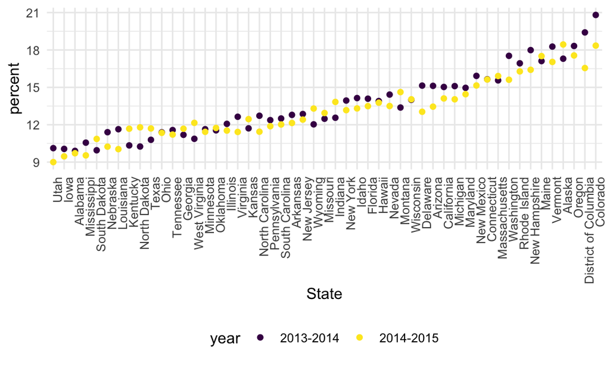

```r
data_marj |>
  filter(age == "12-17") |>
  mutate(State = fct_reorder(State, percent)) |>
  ggplot(aes(x = State, y = percent, color = year)) +
    geom_point() +
    theme(axis.text.x = element_text(angle = 90, hjust = 1))
```

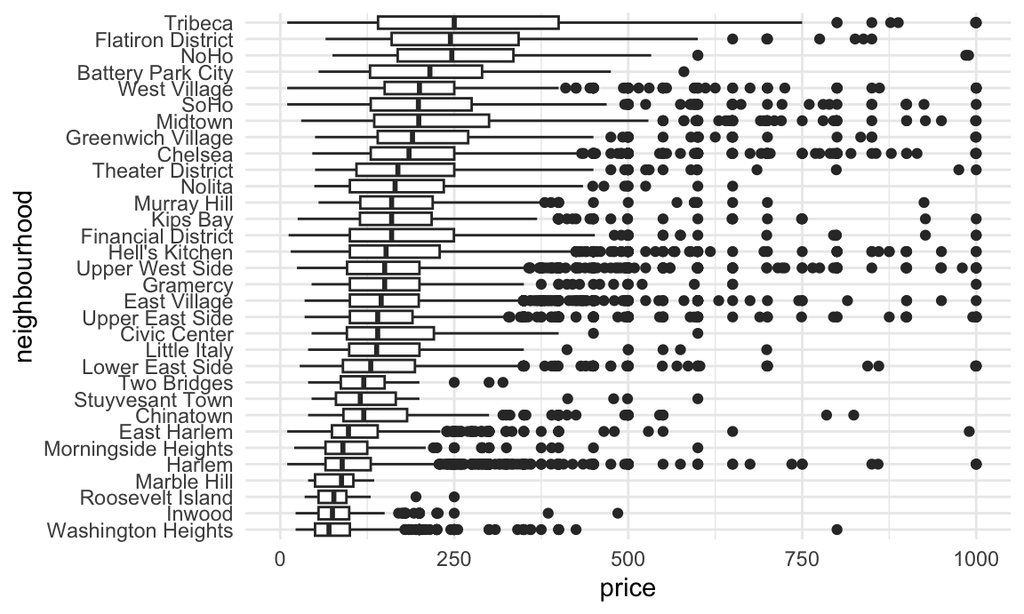

```r
data("nyc_airbnb")

nyc_airbnb |>
  filter(neighbourhood_group == "Manhattan") |>
  mutate(
    neighbourhood = fct_reorder(neighbourhood, price)) |>
  ggplot(aes(x = neighbourhood, y = price)) +
  geom_boxplot() +
  coord_flip() +
  ylim(0, 1000)
```

### Restaurant inspections

As a kind of involved example of strings and factors, we’ll take a look at the NYC Restuarant Inspections data. Although we won’t talk about this in detail now, it’s worth mentioning that these data were collected using the NYC Open Data API; code is available with the data description.

First we’ll import the data, clean a variable name, and take a quick look.

```r
data("rest_inspec")

rest_inspec =
    rest_inspec |>
    rename(borough = boro)


rest_inspec |>
  group_by(borough, grade) |>
  summarize(n = n()) |>
  pivot_wider(names_from = grade, values_from = n)
```

[output not shown]

```
## # A tibble: 6 × 9
## # Groups:   borough [6]
##   borough           A     B     C  `NA`     N     P     Z     G
##   <chr>         <int> <int> <int> <int> <int> <int> <int> <int>
## 1 0                33     9     6    67    NA    NA    NA    NA
## 2 Bronx         14071  2611   976 17190   161   236   605    NA
## 3 Brooklyn      38896  6423  2194 49825   345   782  1168     2
## 4 Manhattan     61675  9107  3600 76581   591   924  1816     3
## 5 Queens        36258  5526  1996 44136   350   604  1287    NA
## 6 Staten Island  5410   855   248  6315    71    61   116    NA
```

To simplify things, I’ll remove inspections with scores other than `A`, `B`, or `C`, and also remove the restaurants with missing borough information. I’ll also clean up borough names a bit.

```r
rest_inspec =
  rest_inspec |>
  filter(grade %in% c("A", "B", "C"), borough != "0") |>
  mutate(borough = str_to_title(borough))

rest_inspec |>
  group_by(borough, grade) |>
  summarize(n = n()) |>
  pivot_wider(names_from = grade, values_from = n)
```

[output not shown]

```
## # A tibble: 5 × 4
## # Groups:   borough [5]
##   borough           A     B     C
##   <chr>         <int> <int> <int>
## 1 Bronx         14071  2611   976
## 2 Brooklyn      38896  6423  2194
## 3 Manhattan     61675  9107  3600
## 4 Queens        36258  5526  1996
## 5 Staten Island  5410   855   248
```

Look for pizza places

```r
rest_inspec |>
  filter(str_detect(dba, "Pizza")) |> # a lot of only uppercase in dba column
  count(borough, grade) |>
  pivot_wider(names_from = grade, values_from = n)
```

```
## # A tibble: 4 × 3
##   borough       A     B
##   <chr>     <int> <int>
## 1 Bronx        15     3
## 2 Brooklyn     15    NA
## 3 Manhattan    13     3
## 4 Queens       11     4
```

That doesn’t look right – for sure there are more pizza place ratings than that! The problem is that the match in `str_detect` is case-sensitive until we tell it not to be:

```r
rest_inspec |>
  filter(str_detect(dba, "[Pp][Ii][Zz][Zz][Aa]")) |>
  group_by(borough, grade) |>
  summarize(n = n()) |>
  pivot_wider(names_from = grade, values_from = n)
```

[output not shown]

```
## # A tibble: 5 × 4
## # Groups:   borough [5]
##   borough           A     B     C
##   <chr>         <int> <int> <int>
## 1 Bronx          1201   261    98
## 2 Brooklyn       1919   291    95
## 3 Manhattan      2091   400    96
## 4 Queens         1695   239    78
## 5 Staten Island   328    60    15
```

```r
rest_inspec |>
  mutate(dba = str_to_upper(dba)) |>
  filter(str_detect(dba, "PIZZA")) |>
  group_by(borough, grade) |>
  summarize(n = n()) |>
  pivot_wider(names_from = grade, values_from = n)
```

[output not shown]

```
## # A tibble: 5 × 4
## # Groups:   borough [5]
##   borough           A     B     C
##   <chr>         <int> <int> <int>
## 1 Bronx          1201   261    98
## 2 Brooklyn       1919   291    95
## 3 Manhattan      2091   400    96
## 4 Queens         1695   239    78
## 5 Staten Island   328    60    15
```

The table is okay but I’d like to visualize this.

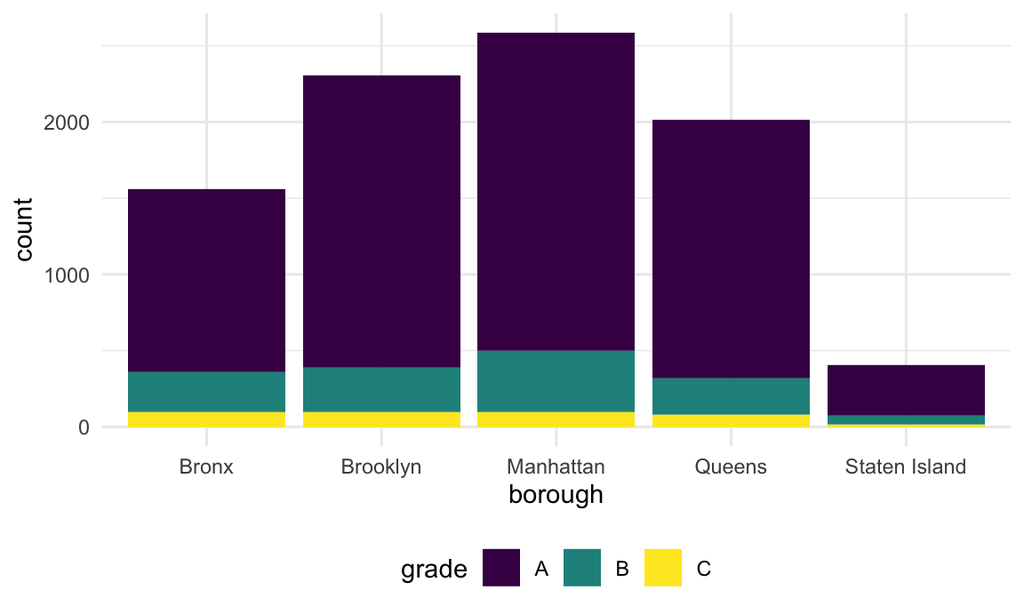

```r
rest_inspec |>
  mutate(dba = str_to_upper(dba)) |>
  filter(str_detect(dba, "PIZZA")) |>
  ggplot(aes(x = borough, fill = grade)) +
  geom_bar()
```

Might help to have things in a different order – maybe number of pizza places? Fortunately this can be done using `fct_infreq`.

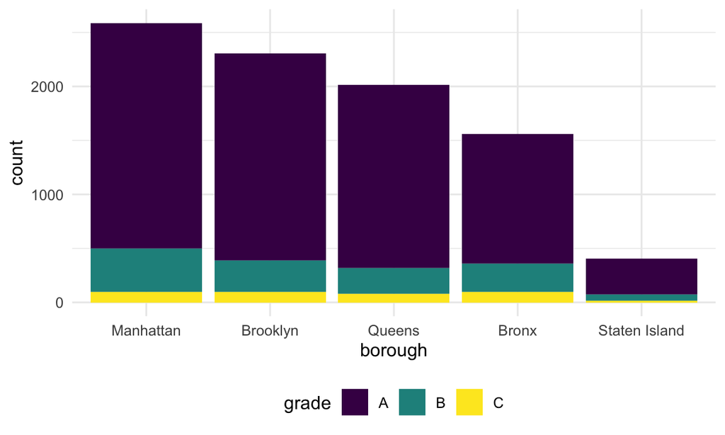

```r
rest_inspec |>
  mutate(dba = str_to_upper(dba), borough = fct_infreq(borough)) |> #orders by frequency
  filter(str_detect(dba, "PIZZA")) |>
  ggplot(aes(x = borough, fill = grade)) +
  geom_bar()
```

Suppose I want to rename a borough. I could try using `str_replace`.

This doesn’t work

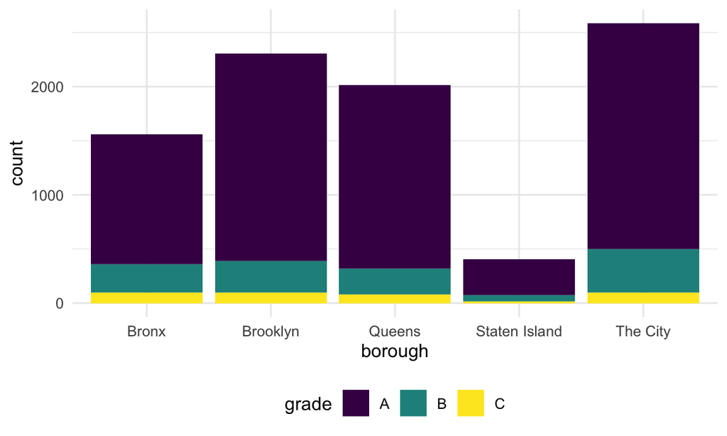

```r
rest_inspec |>
  mutate(dba = str_to_upper(dba)) |>
  filter(str_detect(dba, "PIZZA")) |>
  mutate(
    borough = fct_infreq(borough), #infreq first
    borough = str_replace(borough, "Manhattan", "The City")) |> #str only works on char vars --> puts everything back in alphabetical order
  ggplot(aes(x = borough, fill = grade)) +
  geom_bar()
```

This renamed the borough, but then converted the result back to a string – which, when plotted, was implicitly made a factor and ordered alphabetically. I could switch the order in which I rename and encode the factor order I want, but that might not always work.

If I tried base R (maybe because I found some code online), I might try to do this using `replace`. (also wrong!!)

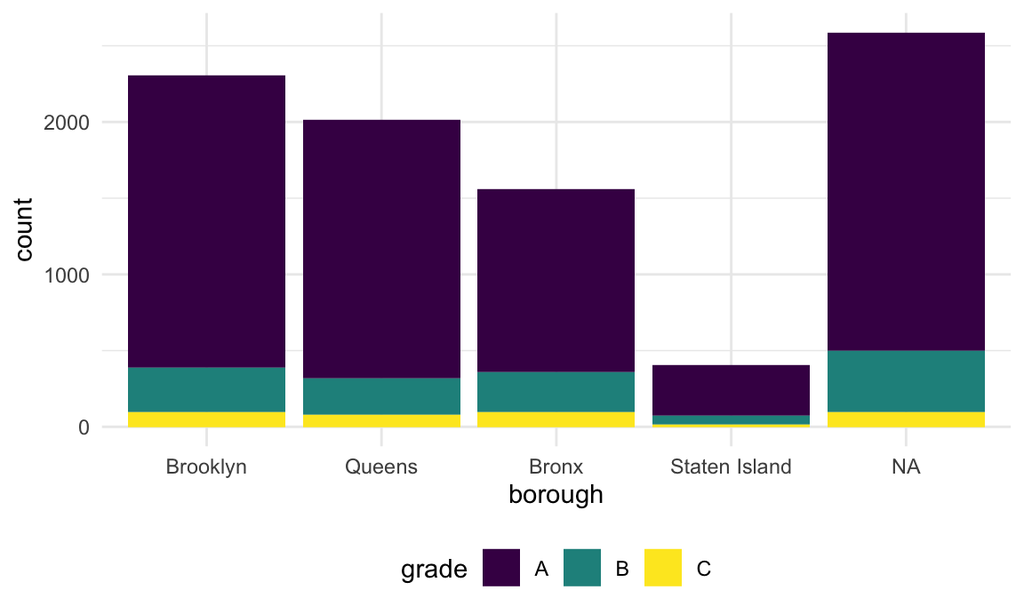

```r
rest_inspec |>
  mutate(dba = str_to_upper(dba)) |>
  filter(str_detect(dba, "PIZZA")) |>
  mutate(
    borough = fct_infreq(borough),
    borough = replace(borough, which(borough == "Manhattan"), "The City")) |>
  ggplot(aes(x = borough, fill = grade)) +
  geom_bar()
```

That didn’t work at all! Factors have very specific values, trying to use a value that is not an existing factor level won’t work.

Fortunately there is a dedicated function for renaming factor levels:

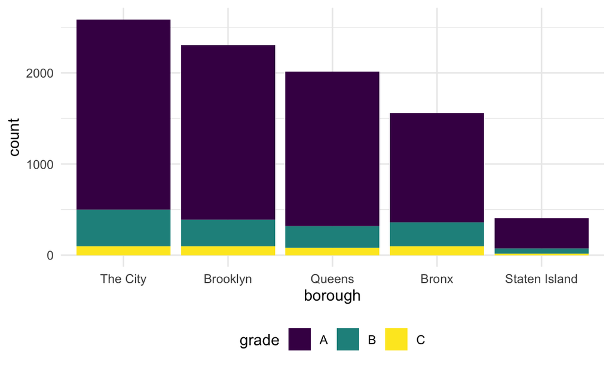

```r
rest_inspec |>
  filter(str_detect(dba, regex("pizza", ignore_case = TRUE))) |>
  mutate(
    borough = fct_infreq(borough),
    borough = fct_recode(borough, "The City" = "Manhattan")) |>
  ggplot(aes(x = borough, fill = grade)) +
  geom_bar()
```

Success!